# 2017-03-07-amazon-reviews-wordcloud

Kasia Kulma

In the last month I discovered two things that changed my life: audiobooks and [Yuval Harari](https://en.wikipedia.org/wiki/Yuval_Noah_Harari). The former completely transformed my daily commute, the latter changed the way I think about the surrounding world (with more appreciation for history and politics, to say the least). The cocktail of the two made my brain cells sing.

Harari published two books in the last three years: [Sapiens: A Brief History of Humankind](https://www.amazon.co.uk/Sapiens-Humankind-Yuval-Noah-Harari/dp/1846558239) and more recently: [Homo Deus: A Brief History of Tomorrow](https://www.amazon.co.uk/Homo-Deus-Brief-History-Tomorrow/dp/1910701874/). Both perspective - changing, right?

My opinions aside, what do other readers think about his books? Let’s dig into it by scraping Amazon reviews of “Sapiens” and then visualising their most common words in a wordcloud.

### loading packages

```r
install.packages("pacman", repos = "http://cran.us.r-project.org")
pacman::p_load(XML, dplyr, stringr, rvest, xml2) # web-scraping
pacman::p_load(tm, rvest, SnowballC, wordcloud) # wordcloud-building
```

### importing Amazon reviews for Yuval Harari’s “Sapiens”

The web-scraping procedures that follow were shamelessly “borrowed” from [Riki Saito’s blog](https://justrthings.wordpress.com/2016/08/17/web-scraping-and-sentiment-analysis-of-amazon-reviews/). Thanks, mate!

The following code requires *Amazon’s product code*, which can be found in the product’s URL. Next, it scrapes the product’s name, just to confirm we got everything right!

```r
# define a function removing all white space
trim <- function (x) gsub("^\\s+|\\s+$", "", x)

# define product code and the url
prod_code = "1846558239"
url <- paste0("https://www.amazon.co.uk/dp/", prod_code)
doc <- xml2::read_html(url)

#obtain the text in the node, remove "\n" from the text, and remove white space
prod <- html_nodes(doc, "#productTitle") %>% html_text() %>% gsub("\n", "", .) %>% trim()
prod
```

```
## [1] "Sapiens: A Brief History of Humankind"
```

```r
# THE KEY: Source function to parse Amazon html pages for data
source("https://raw.githubusercontent.com/rjsaito/Just-R-Things/master/Text%20Mining/amazonscraper.R")
```

```r
pages <- 10

reviews_all <- NULL

for(page_num in 1:pages){
  url2 <- paste0("http://www.amazon.co.uk/product-reviews/",prod_code,"/?pageNumber=", page_num)
  doc2 <- read_html(url2)

  reviews <- amazon_scraper(doc2, reviewer = F, delay = 2)
  reviews_all <- rbind(reviews_all, reviews)
}
```

It looks like everything worked! The returned data frame contains not only date, title, author and content of every review, but also number of stars given, format of the book that the review is for and even the number of people that thought this particular review is helpful, priceless!

```r
str(reviews_all)
```

```
## 'data.frame':    100 obs. of  8 variables:
##  $ title       : chr  "A subjective history of Humankind" "Insights on every page" "Thrilling iconoclastic book of human history" "Good view of the past, questionnable view of the future" ...
##  $ author      : chr  "Strv 74" "M. D. Holley" "Wasim Zarniwoop" "Hugo" ...
##  $ date        : chr  "17 November 2014" "27 September 2014" "10 September 2014" "19 January 2015" ...
##  $ ver.purchase: num  1 0 1 1 0 1 0 1 1 0 ...
##  $ format      : chr  "Format: Hardcover" "Format: Hardcover" "Format: Kindle Edition" "Format: Paperback" ...
##  $ stars       : num  4 5 5 3 5 4 5 5 2 1 ...
##  $ comments    : chr  "This book looked interesting and I bought it without having read up on everything about it. I thought is was about how we came "| __truncated__ "Beautifully written, this book contains one incredible idea: that the success of homo sapiens derives from our inclination to b"|…
##  $ helpful     : num  109 174 89 120 54 39 67 2 26 73 ...
```

In this post I’ll focus on the review content only. Here’s what the exemplary comment looks like:

```r
reviews_all[1, 7]
```

```
## [1] "This book looked interesting and I bought it without having read up on everything about it. I thought is was about how we came to be the one surviving race of Humans on the planet. It was not. That was taken care of during the first 20 pages. The Rest is about how the single surviving human …
```

As you can tell, it’s not in the best shape for the analysis: it contains punctuation signs, numbers, lower and upper letters, etc. Let’s sort it out by doing some text pre-processing:

### text pre-processing

```r
#### creating corpus
m <- list(content = "comments")
myReader <- readTabular(mapping = m)

final_reviews <- data.frame(comments = reviews_all$comments)
ds <- DataframeSource(final_reviews)

## create corpus with all the reviews
sapiens_corpus <- VCorpus(ds)

## remove punctuation
sapiens_corpus = tm_map(sapiens_corpus, removePunctuation)

## remove numbers
sapiens_corpus = tm_map(sapiens_corpus, removeNumbers)

## LowerCase
sapiens_corpus = tm_map(sapiens_corpus, tolower)
```

I also removed some uninformative words, together with English stopwords, to make the results clearer:

```r
## remove stopwords and other words
myWords=c("format", "paperback", "kindle", "edit", "hardcov", "book", "read", "will", "just", "can", "much")

sapiens_corpus <- tm_map(sapiens_corpus, removeWords, c(stopwords("english"), myWords))

## treat pre-processed documents as text documents
sapiens_corpus <- tm_map(sapiens_corpus, PlainTextDocument)

## turn into doc matrix
sapiens_dtm <- DocumentTermMatrix(sapiens_corpus)
```

Let’s have a quick peek into the top 20 most frequent words:

```r
# displaying most frequent words
freq <- sort(colSums(as.matrix(sapiens_dtm)), decreasing=TRUE)
head(freq, 20)
```

```
##     history       human      author         one     sapiens      harari
##         106          75          64          61          61          46
##        many      people     reading         way        well        even
##          44          43          40          37          37          36
## interesting       world      really        homo      humans        like
##          36          36          35          34          34          34
##       think       years
##          34          33
```

And finally, crème de la crème, **the wordcloud** showing 250 most frequent words found in Amazon reviews of *“Sapiens”*:

### creating a wordcloud with the top 250 most frequent words

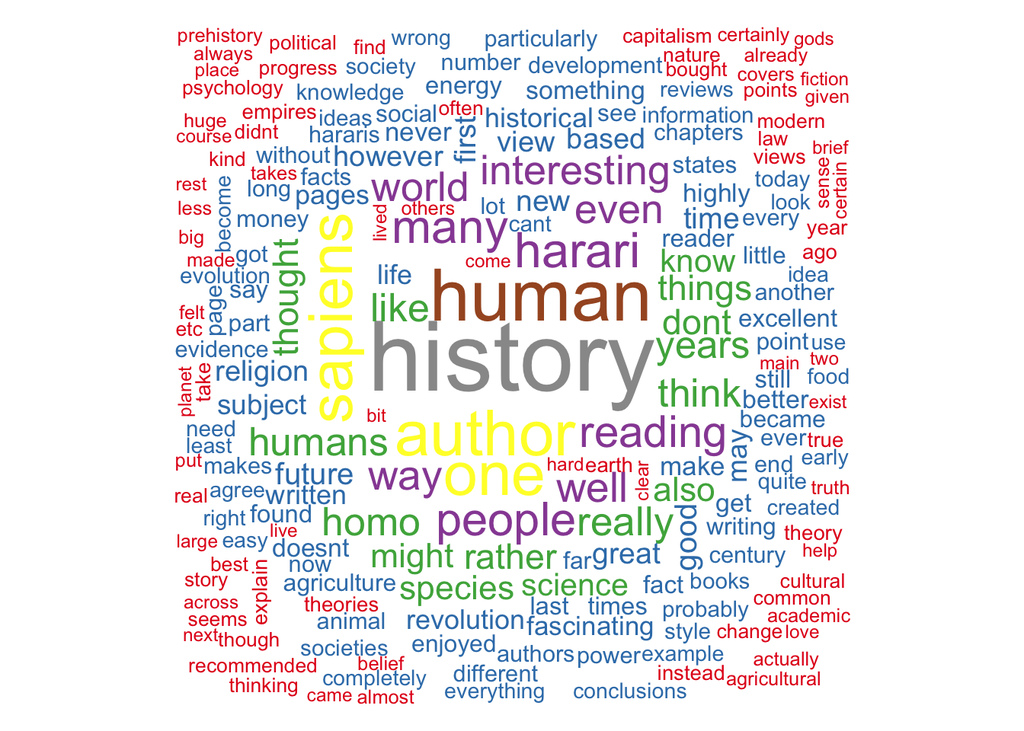

```r
pal=brewer.pal(9, "Set1")

set.seed(100)
wordcloud(words = names(freq), freq = freq, max.words=250,
          random.order=FALSE,
          colors=pal)
```